# Distributions in R

# Introduction to Probability Functions in R

R provides a suite of functions for working with probability distributions. Each distribution has four variants, specified by a prefix letter:

- `d`: Density/probability mass function (PDF/PMF)
- `p`: Cumulative distribution function (CDF)
- `q`: Quantile function (inverse CDF)
- `r`: Random number generation

For example, for the normal distribution: - `dnorm()`: PDF value at x - `pnorm()`: Probability of X ≤ x - `qnorm()`: Value of x at given probability - `rnorm()`: Generate random numbers

Let’s explore each major distribution:

## 1. Normal Distribution

The normal distribution is defined by its mean (μ) and standard deviation (σ).

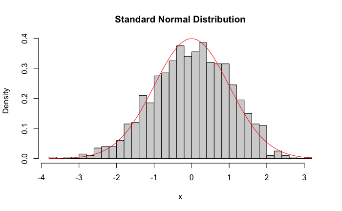

```r
# Generate random normal numbers
x <- rnorm(1000, mean = 0, sd = 1)
hist(x, breaks = 30, prob = TRUE, main = "Standard Normal Distribution")
curve(dnorm(x), add = TRUE, col = "red")
```

```r
# PDF at specific points
dnorm(0)  # Density at mean
```

```
[1] 0.3989423
```

```
#> [1] 0.3989423
```

```r
dnorm(1)  # Density at one SD
```

```
[1] 0.2419707
```

```
#> [1] 0.2419707
```

```r
# CDF - probability of X ≤ 1.96 (95% confidence interval)
pnorm(1.96)
```

```
[1] 0.9750021
```

```
#> [1] 0.9750021
```

```r
# Quantile - find value at 97.5th percentile
qnorm(0.975)
```

```
[1] 1.959964
```

```
#> [1] 1.959964
```

## 2. Binomial Distribution

The binomial distribution models the number of successes in n independent trials with probability p.

```r
# Probability of exactly 3 successes in 5 trials with p=0.5
dbinom(3, size = 5, prob = 0.5)
```

```
[1] 0.3125
```

```
#> [1] 0.3125
```

```r
# Probability of 3 or fewer successes
pbinom(3, size = 5, prob = 0.5)
```

```
[1] 0.8125
```

```
#> [1] 0.8125
```

```r
# Generate 10 random binomial numbers
rbinom(10, size = 5, prob = 0.5)
```

```
 [1] 4 0 3 3 3 4 3 4 1 4
```

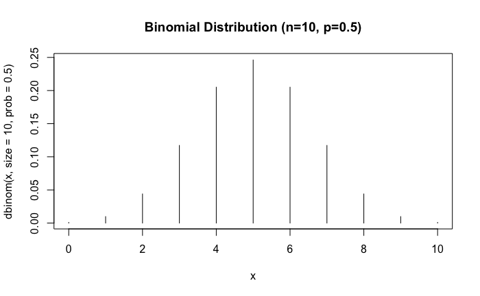

```r
# Plot probability mass function
x <- 0:10
plot(x, dbinom(x, size = 10, prob = 0.5), type = "h",
     main = "Binomial Distribution (n=10, p=0.5)")
```

## 3. Poisson Distribution

The Poisson distribution models rare events, with parameter λ representing the average rate.

```r
# Probability of exactly 2 events when mean is 1
dpois(2, lambda = 1)
```

```
[1] 0.1839397
```

```
#> [1] 0.1839397
```

```r
# Probability of 2 or fewer events
ppois(2, lambda = 1)
```

```
[1] 0.9196986
```

```
#> [1] 0.9196986
```

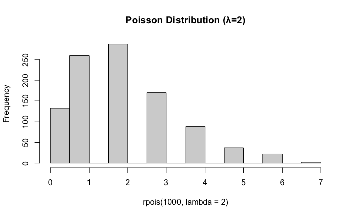

```r
# Generate random Poisson numbers
rpois(1000, lambda = 2) |>
  hist(main = "Poisson Distribution (λ=2)")
```

## 4. Uniform Distribution

The uniform distribution models equal probability across an interval.

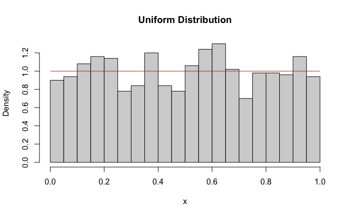

```r
# Generate uniform random numbers
x <- runif(1000, min = 0, max = 1)
hist(x, breaks = 30, prob = TRUE, main = "Uniform Distribution")
curve(dunif(x, 0, 1), add = TRUE, col = "red")
```

```r
# PDF is constant between min and max
dunif(0.5, min = 0, max = 1)
```

```
[1] 1
```

```
#> [1] 1
```

```r
# CDF increases linearly
punif(0.5, min = 0, max = 1)
```

```
[1] 0.5
```

```
#> [1] 0.5
```

## 5. Chi-Square Distribution

The chi-square distribution with k degrees of freedom is the sum of k squared standard normal variables.

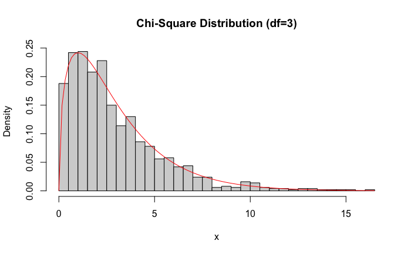

```r
# Generate chi-square random numbers
x <- rchisq(1000, df = 3)
hist(x, breaks = 30, prob = TRUE, main = "Chi-Square Distribution (df=3)")
curve(dchisq(x, df = 3), add = TRUE, col = "red")
```

```r
# Critical value for 95% confidence
qchisq(0.95, df = 3)
```

```
[1] 7.814728
```

```
#> [1] 7.814728
```

## 6. Student’s t Distribution

The t-distribution is similar to normal but has heavier tails, useful for small samples.

```r
# Compare t vs normal densities
curve(dt(x, df = 3), from = -4, to = 4, col = "red",
      main = "t vs Normal Distribution")
curve(dnorm(x), add = TRUE, col = "blue")
```

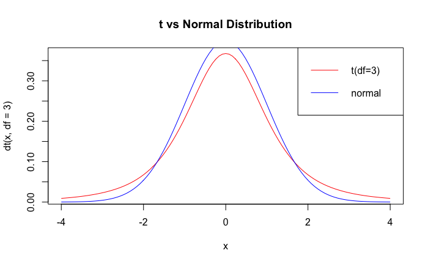

```r
legend("topright", c("t(df=3)", "normal"), col = c("red", "blue"), lty = 1)
```

```r
# Critical value for 95% confidence, df=10
qt(0.975, df = 10)
```

```
[1] 2.228139
```

```
#> [1] 2.228139
```

## 7. F Distribution

The F distribution is used in ANOVA and regression analysis.

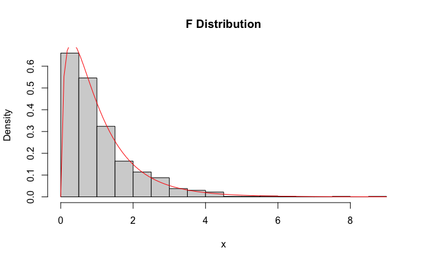

```r
# Generate F-distributed random numbers
x <- rf(1000, df1 = 3, df2 = 20)
hist(x, breaks = 30, prob = TRUE, main = "F Distribution")
curve(df(x, df1 = 3, df2 = 20), add = TRUE, col = "red")
```

```r
# Critical value for 95% confidence
qf(0.95, df1 = 3, df2 = 20)
```

```
[1] 3.098391
```

```
#> [1] 3.098391
```

## Common Use Cases

1. Normal Distribution:
   - Confidence intervals
   - Statistical inference
   - Modeling natural phenomena
2. Binomial Distribution:
   - A/B testing
   - Quality control
   - Success/failure experiments
3. Poisson Distribution:
   - Modeling rare events
   - Queue theory
   - Count data
4. Uniform Distribution:
   - Random number generation
   - Simulation studies
   - Testing algorithms
5. Chi-Square Distribution:
   - Goodness of fit tests
   - Tests of independence
   - Variance analysis
6. Student’s t Distribution:
   - Small sample inference
   - Confidence intervals
   - Hypothesis testing
7. F Distribution:
   - ANOVA
   - Model comparison
   - Variance ratio tests

## Practical Tips

1. Always check your parameters:

```r
# This will give a warning
rnorm(10, sd = -1)
```

```
 [1] NaN NaN NaN NaN NaN NaN NaN NaN NaN NaN
```

2. Use `set.seed()` for reproducible results:

```r
set.seed(123)
rnorm(3)
```

```
[1] -0.5604756 -0.2301775  1.5587083
```

```r
set.seed(123)
rnorm(3)  # Same numbers
```

```
[1] -0.5604756 -0.2301775  1.5587083
```

3. For probabilities, remember:
   - `d` functions return height of PDF/PMF
   - `p` functions return area (probability)
   - `q` functions are inverse of `p`
   - `r` functions generate random numbers